# Titanic Data Analysis

## Discription

This discription of titanic was taken from [Kaggle](https://www.kaggle.com/c/titanic)

> The sinking of the RMS Titanic is one of the most infamous shipwrecks in history. On April 15, 1912, during her maiden voyage, the Titanic sank after colliding with an iceberg, killing 1502 out of 2224 passengers and crew. This sensational tragedy shocked the international community and led to better safety regulations for ships.

> One of the reasons that the shipwreck led to such loss of life was that there were not enough lifeboats for the passengers and crew. Although there was some element of luck involved in surviving the sinking, some groups of people were more likely to survive than others, such as women, children, and the upper-class.

## Aim

To performe Data analysis on the give data which is a sample of the orignal data.

## Questions which could be asked

- Were the socio-ecenomic condition could be a factor for the survival?
- were the age of passanges could be a factor for survival?
- were elders, womens or childrens could be given priority to lifeboata?
- were the sex of passanges could be a factor for survival?
- were there any substantial difference in survival between the people with siblings, parents and childrens **and** the people with no sibling, parents and childrens?

## Data extraction and cleaning

```python
# Rendering plots inline
%matplotlib inline

# Importing libraries
import pandas as pd
import numpy as np
import matplotlib.pyplot as plt
import seaborn as sns

# uploading the data as data frames
titanic_data = pd.read_csv('titanic-data.csv')
```

```python
titanic_data.head()
```

|  | PassengerId | Survived | Pclass | Name | Sex | Age | SibSp | Parch | Ticket | Fare | Cabin | Embarked |
| --- | --- | --- | --- | --- | --- | --- | --- | --- | --- | --- | --- | --- |
| 0 | 1 | 0 | 3 | Braund, Mr. Owen Harris | male | 22.0 | 1 | 0 | A/5 21171 | 7.2500 | NaN | S |
| 1 | 2 | 1 | 1 | Cumings, Mrs. John Bradley (Florence Briggs Th... | female | 38.0 | 1 | 0 | PC 17599 | 71.2833 | C85 | C |
| 2 | 3 | 1 | 3 | Heikkinen, Miss. Laina | female | 26.0 | 0 | 0 | STON/O2. 3101282 | 7.9250 | NaN | S |
| 3 | 4 | 1 | 1 | Futrelle, Mrs. Jacques Heath (Lily May Peel) | female | 35.0 | 1 | 0 | 113803 | 53.1000 | C123 | S |
| 4 | 5 | 0 | 3 | Allen, Mr. William Henry | male | 35.0 | 0 | 0 | 373450 | 8.0500 | NaN | S |

```python
titanic_data.tail()
```

|  | PassengerId | Survived | Pclass | Name | Sex | Age | SibSp | Parch | Ticket | Fare | Cabin | Embarked |
| --- | --- | --- | --- | --- | --- | --- | --- | --- | --- | --- | --- | --- |
| 886 | 887 | 0 | 2 | Montvila, Rev. Juozas | male | 27.0 | 0 | 0 | 211536 | 13.00 | NaN | S |
| 887 | 888 | 1 | 1 | Graham, Miss. Margaret Edith | female | 19.0 | 0 | 0 | 112053 | 30.00 | B42 | S |
| 888 | 889 | 0 | 3 | Johnston, Miss. Catherine Helen "Carrie" | female | NaN | 1 | 2 | W./C. 6607 | 23.45 | NaN | S |
| 889 | 890 | 1 | 1 | Behr, Mr. Karl Howell | male | 26.0 | 0 | 0 | 111369 | 30.00 | C148 | C |
| 890 | 891 | 0 | 3 | Dooley, Mr. Patrick | male | 32.0 | 0 | 0 | 370376 | 7.75 | NaN | Q |

### Removing duplicates

we first remove the duplicate entries(if any) from the data set.

```python
print 'There are total {} rows in the data set'.format(len(titanic_data))
# removing the duplicate entries
titanic_clean_data = titanic_data.drop_duplicates()

print 'There are total {} rows in the data set'.format(len(titanic_clean_data))
```

```
There are total 891 rows in the data set
There are total 891 rows in the data set
```

We see that the row count is still the same, that means there were not any duplicates in the data.

There are many entries which hava age missing. So we are going to see how many rows are there with NaN age and how it will effect our data analysis.

```python
missing_age = titanic_clean_data['Age'].isnull()
print '{} passangers whose age is missing.'.format(missing_age.sum())
print '{} male passangers whose age is missing.'.format((titanic_clean_data[missing_age]['Sex'] == 'male').sum())
print '{} female passangers whose age is missing.'.format((titanic_clean_data[missing_age]['Sex'] == 'female').sum())
```

```
177 passangers whose age is missing.
124 male passangers whose age is missing.
53 female passangers whose age is missing.
```

So missing ages are a lot, it will effect out data analysis, especially for males.

So we are going to make a variable which contain the info of passangers who has age. And we use this variable where we need to analyse the data by age.

```python
#dropping the rows where age is missing
passangers_with_age = titanic_clean_data[['Survived','Sex','Pclass','Age','SibSp','Parch','Fare']].dropna(axis = 0)

#description of rows remained
passangers_with_age.info()
```

```
<class 'pandas.core.frame.DataFrame'>
Int64Index: 714 entries, 0 to 890
Data columns (total 7 columns):
Survived    714 non-null int64
Sex         714 non-null object
Pclass      714 non-null int64
Age         714 non-null float64
SibSp       714 non-null int64
Parch       714 non-null int64
Fare        714 non-null float64
dtypes: float64(2), int64(4), object(1)
memory usage: 44.6+ KB
```

## Statistical analysis and exploration of data

```python
titanic_clean_data[['Survived','Pclass','Age','SibSp','Parch','Fare']].describe()
```

|  | Survived | Pclass | Age | SibSp | Parch | Fare |
| --- | --- | --- | --- | --- | --- | --- |
| count | 891.000000 | 891.000000 | 714.000000 | 891.000000 | 891.000000 | 891.000000 |
| mean | 0.383838 | 2.308642 | 29.699118 | 0.523008 | 0.381594 | 32.204208 |
| std | 0.486592 | 0.836071 | 14.526497 | 1.102743 | 0.806057 | 49.693429 |
| min | 0.000000 | 1.000000 | 0.420000 | 0.000000 | 0.000000 | 0.000000 |
| 25% | 0.000000 | 2.000000 | 20.125000 | 0.000000 | 0.000000 | 7.910400 |
| 50% | 0.000000 | 3.000000 | 28.000000 | 0.000000 | 0.000000 | 14.454200 |
| 75% | 1.000000 | 3.000000 | 38.000000 | 1.000000 | 0.000000 | 31.000000 |
| max | 1.000000 | 3.000000 | 80.000000 | 8.000000 | 6.000000 | 512.329200 |

### Visualisation about the data

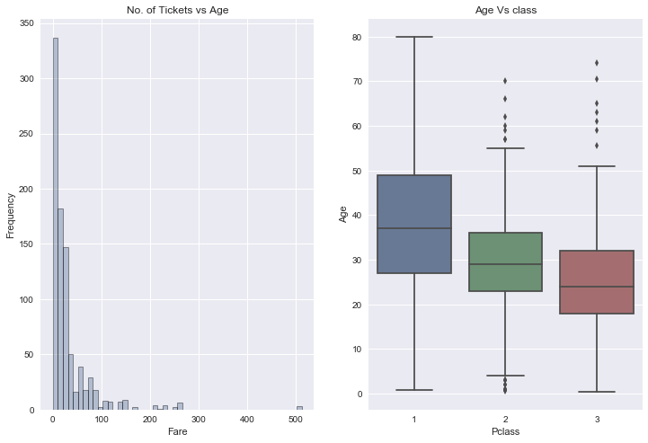

```python
# setting the size of the graph
sns.set_palette("deep",desat=.6)
sns.set_context(rc={'figure.figsize':(12,8)})
price_plot, axs = plt.subplots(1,2)

#setting the labels
axs[0].set_ylabel('Frequency')
axs[0].set_title('No. of Tickets vs Age')
axs[1].set_ylabel('Age')
axs[1].set_title('Age Vs class')

#showing the plots
sns.distplot(titanic_clean_data['Fare'],kde=False,hist_kws=dict(edgecolor="k", linewidth=1),axlabel='Fare',ax=axs[0]);
sns.boxplot(x='Pclass',y='Age',data=titanic_clean_data[['Age','Pclass']],ax=axs[1])
```

- From the first graph we can see that most of the passanger bought the cheeper class rather than expensive, so most of them seems like buy the ticket for class 3.
- From the second graph we can see that the median age for class 1 greater than class 2 and class 3. Surely the class 1 passangers were a little older than the passangers in other classes.

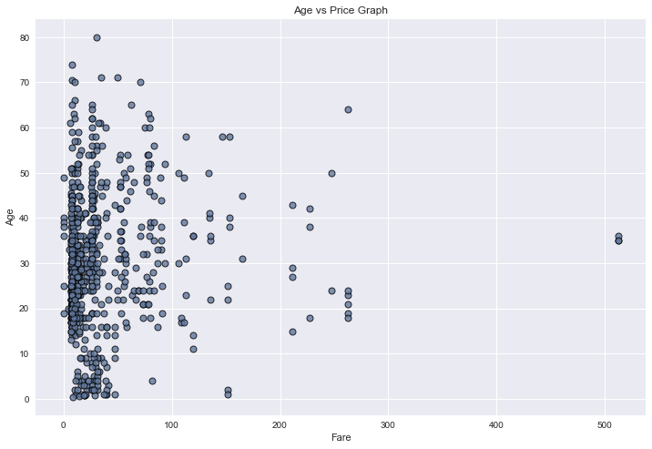

```python
#setting the title
sns.plt.title('Age vs Price Graph')

#showing the plot
sns.regplot(x="Fare", y="Age", data=titanic_clean_data[['Age','Fare']],scatter_kws=dict(edgecolor="k", linewidth=1),fit_reg=False)
```

here we see a little bit clear picture that people from all age group buy cheaper ticket but mostly between the age group 15 to 50.

## Visualizing and analysing our questions

lets drop out the columns which we are not gonna use.

```python
titanic_more_clean_data = titanic_clean_data.drop(['PassengerId','Name','Ticket','Cabin','Fare','Embarked'], axis=1)
```

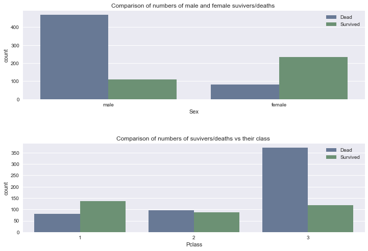

```python
#making cell for multiple plots
fig, (ax1, ax2) = plt.subplots(2)
fig.subplots_adjust(hspace=.5)

#setting the title
ax1.set_title('Comparison of numbers of male and female suvivers/deaths ')
ax2.set_title('Comparison of numbers of suvivers/deaths vs their class ')

#showing the plot
sns.countplot(x = "Sex", hue = "Survived", data=titanic_more_clean_data, ax = ax1)
ax1.legend(('Dead','Survived'),loc='best')

#showing the plot
sns.countplot(x = "Pclass", hue = "Survived", data=titanic_more_clean_data, ax = ax2)
ax2.legend(('Dead','Survived'),loc='best')
```

From the above two plots we can answer our two questions.

- Were the socio-ecenomic condition could be a factor for the survival?
- were the sex of passanges could be a factor for survival?

**As we can see that female survivors are much higher than the male survivors from the above graph, so sex could be a factor.**

**As we can see that maximum no of the survivors belongs to the class 1, so we can say that socio-economic condition could be a factor for survival.**

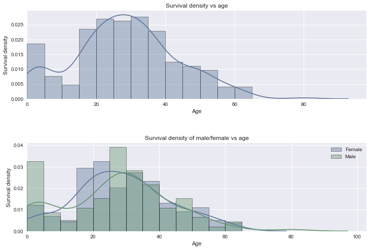

```python
# plotting a histogram to depict the relation between survival and age
fig, (ax1, ax2) = plt.subplots(2)
sns.distplot(passangers_with_age[(passangers_with_age['Survived'] == 1)]['Age'],bins=range(0,80,5),hist_kws=dict(edgecolor="k", linewidth=1),ax=ax1)
sns.distplot(passangers_with_age[(passangers_with_age['Survived'] == 1) & \
                                     (passangers_with_age['Sex'] == 'female')]['Age'],bins=range(0,80,5),hist_kws=dict(edgecolor="k", linewidth=1),ax=ax2)
sns.distplot(passangers_with_age[(passangers_with_age['Survived'] == 1) & \
                                     (passangers_with_age['Sex'] == 'male')]['Age'],bins=range(0,80,5),hist_kws=dict(edgecolor="k", linewidth=1),ax=ax2)

fig.subplots_adjust(hspace=.5)

#Setting the labels and titles
ax1.set_ylabel('Survival density')
ax1.set_xlim(0)
ax1.set_title('Survival density vs age')
ax2.set_ylabel('Survival density')
ax2.set_xlim(0)
ax2.set_title('Survival density of male/female vs age')
ax2.legend(('Female','Male'),loc='best')
```

### take aways from the above graphs

**Note that I am using the variable passangers_with_age which has the info of only those passangers whose age is available in the data set.**

- From the First graph we can say that the adults between 20 to 40 were give higher proirity followed by children, mostly new borns and aged between 0 to 5.
- From the second graph it looks like women were given a very little more priority than men for survival, but it is not much clear from the graph.

#### lets look the second graph closely for elders

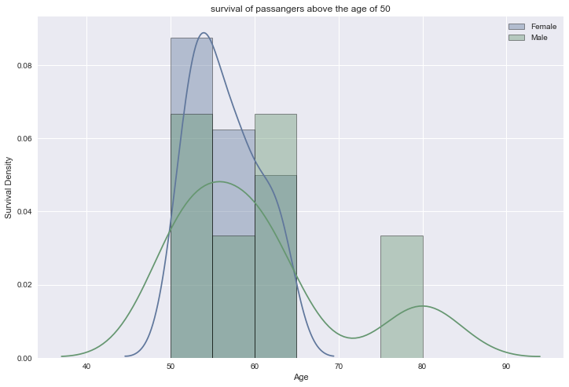

```python
#putting the title
plt.title('survival of passangers above the age of 50')

#showing the plot
sns.distplot(passangers_with_age[(passangers_with_age['Survived'] == 1) & \
                                     (passangers_with_age['Sex'] == 'female') & \
                                    (passangers_with_age['Age'] > 50 )]['Age'], hist_kws=dict(edgecolor="k", linewidth=1),bins=range(40,85,5))

sns.distplot(passangers_with_age[(passangers_with_age['Survived'] == 1) & \
                                     (passangers_with_age['Sex'] == 'male') & \
                                    (passangers_with_age['Age'] > 50 )]['Age'], hist_kws=dict(edgecolor="k", linewidth=1),bins=range(40,85,5))
#putting the labels
plt.ylabel('Survival Density')

#putting the legend
plt.legend(('Female','Male'),loc='best')
```

**Here we see that women who were old, were given higher proirity for the survival than the old men.**

the above graphs can answer other two qustions.

- were the age of passanges could be a factor for survival?
- were elders, womens or childrens could be given priority to lifeboata?

  **The childrens were given the higher priority.**

  **Womens were given higher priority, especially to the older womens.**

### Now lets analyse and visualize the data of passanger who have sibling or parents or childrens.

In this section we are going to be discovering that how having or not having sibling,parent or children coul effect the survival of a passanger (we will analyse this both on sex level and als class level).

```python
#filtering data on the basis of their parents and siblings
passangers_with_sib = titanic_more_clean_data[(titanic_more_clean_data['SibSp'] > 0) ]
passangers_with_no_sib = titanic_more_clean_data[(titanic_more_clean_data['SibSp'] == 0) ]
passangers_with_parents_childrens = titanic_more_clean_data[(titanic_more_clean_data['Parch'] > 0) ]
passangers_with_no_parents_childrens = titanic_more_clean_data[(titanic_more_clean_data['Parch'] == 0) ]
passangers_with_parents_but_no_sib = titanic_more_clean_data[(titanic_more_clean_data['SibSp'] == 0) & \
                                                 (titanic_more_clean_data['Parch'] > 0) ]
passangers_with_sib_but_no_parents = titanic_more_clean_data[(titanic_more_clean_data['SibSp'] > 0) & \
                                                 (titanic_more_clean_data['Parch'] == 0) ]
passangers_with_parents_and_sib = titanic_more_clean_data[(titanic_more_clean_data['SibSp'] > 0) & \
                                                 (titanic_more_clean_data['Parch'] > 0) ]
passangers_with_no_parents_and_sib = titanic_more_clean_data[(titanic_more_clean_data['SibSp'] == 0) & \
                                                 (titanic_more_clean_data['Parch'] == 0) ]
print 'there are {} no of passangers who have sibling on the ship'.format(len(passangers_with_sib))
print 'there are {} no of passangers who have no sibling on the ship'.format(len(passangers_with_no_sib))
print 'there are {} no of passangers who have parents or children on the ship'.format(len(passangers_with_parents_childrens))
print 'there are {} no of passangers who have no parents on the ship'.format(len(passangers_with_no_parents_childrens))
print 'there are {} no of passangers who have parents/children but no sibling on the ship'.format(len(passangers_with_parents_but_no_sib))
print 'there are {} no of passangers who have sibling but no parents/children on the ship'.format(len(passangers_with_sib_but_no_parents))
print 'there are {} no of passangers who have both sibling and parents/children on the ship'.format(len(passangers_with_parents_and_sib))
print 'there are {} no of passangers who have neither sibling nor parents/children on the ship'.format(len(passangers_with_no_parents_and_sib))
```

```
there are 283 no of passangers who have sibling on the ship
there are 608 no of passangers who have no sibling on the ship
there are 213 no of passangers who have parents or children on the ship
there are 678 no of passangers who have no parents on the ship
there are 71 no of passangers who have parents/children but no sibling on the ship
there are 141 no of passangers who have sibling but no parents/children on the ship
there are 142 no of passangers who have both sibling and parents/children on the ship
there are 537 no of passangers who have neither sibling nor parents/children on the ship
```

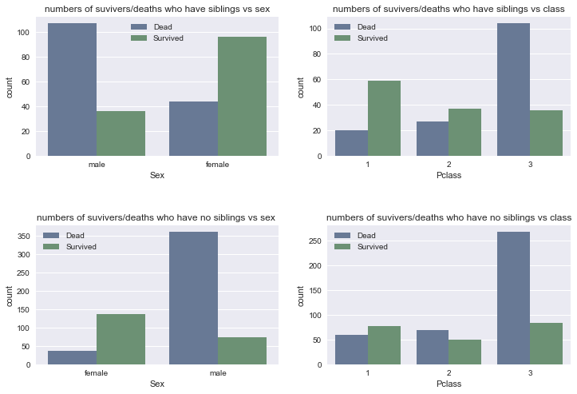

```python
#making cell for multiple plots
fig, ax1 = plt.subplots(2,2)
fig.subplots_adjust(hspace=.5)

#setting the titles
ax1[0][0].set_title('numbers of suvivers/deaths who have siblings vs sex')
ax1[0][1].set_title('numbers of suvivers/deaths who have siblings vs class')
ax1[1][0].set_title('numbers of suvivers/deaths who have no siblings vs sex ')
ax1[1][1].set_title('numbers of suvivers/deaths who have no siblings vs class')

#showing the plots with legends
sns.countplot(x = "Sex", hue = "Survived", data=passangers_with_sib, ax = ax1[0,0])
ax1[0][0].legend(('Dead','Survived'),loc='best')

#showing the plots with legends
sns.countplot(x = "Pclass", hue = "Survived", data=passangers_with_sib, ax = ax1[0,1])
ax1[0][1].legend(('Dead','Survived'),loc='best')

#showing the plots with legends
sns.countplot(x = "Sex", hue = "Survived", data=passangers_with_no_sib, ax = ax1[1,0])
ax1[1][0].legend(('Dead','Survived'),loc='best')

#showing the plots with legends
sns.countplot(x = "Pclass", hue = "Survived", data=passangers_with_no_sib, ax = ax1[1,1])
ax1[1][1].legend(('Dead','Survived'),loc='best')
```

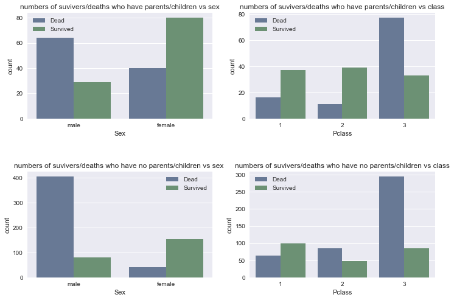

```python
#making the cell for multiple plots
fig, ax1 = plt.subplots(2,2)
fig.subplots_adjust(hspace=.5)

#setting the titles
ax1[0][0].set_title('numbers of suvivers/deaths who have parents/children vs sex')
ax1[0][1].set_title('numbers of suvivers/deaths who have parents/children vs class')
ax1[1][0].set_title('numbers of suvivers/deaths who have no parents/children vs sex ')
ax1[1][1].set_title('numbers of suvivers/deaths who have no parents/children vs class')

#showing the plots with legends
sns.countplot(x = "Sex", hue = "Survived", data=passangers_with_parents_childrens, ax = ax1[0,0])
ax1[0][0].legend(('Dead','Survived'),loc='best')

#showing the plots with legends
sns.countplot(x = "Pclass", hue = "Survived", data=passangers_with_parents_childrens, ax = ax1[0,1])
ax1[0][1].legend(('Dead','Survived'),loc='best')

#showing the plots with legends
sns.countplot(x = "Sex", hue = "Survived", data=passangers_with_no_parents_childrens, ax = ax1[1,0])
ax1[1][0].legend(('Dead','Survived'),loc='best')

#showing the plots with legends
sns.countplot(x = "Pclass", hue = "Survived", data=passangers_with_no_parents_childrens, ax = ax1[1,1])
ax1[1][1].legend(('Dead','Survived'),loc='best')
```

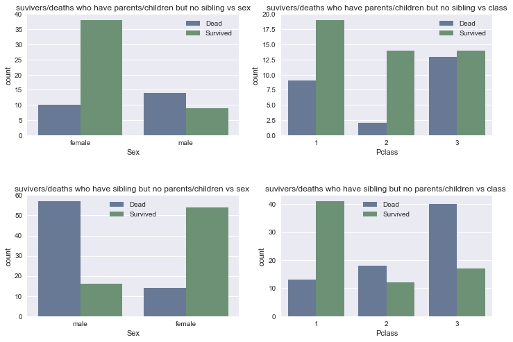

```python
#enabling the cell multiple plots
fig, ax1 = plt.subplots(2,2)
fig.subplots_adjust(hspace=.5)

#setting the titles
ax1[0][0].set_title('suvivers/deaths who have parents/children but no sibling vs sex')
ax1[0][1].set_title('suvivers/deaths who have parents/children but no sibling vs class')
ax1[1][0].set_title('suvivers/deaths who have sibling but no parents/children vs sex ')
ax1[1][1].set_title('suvivers/deaths who have sibling but no parents/children vs class ')

#showing the plots with legends
sns.countplot(x = "Sex", hue = "Survived", data=passangers_with_parents_but_no_sib, ax = ax1[0,0])
ax1[0][0].legend(('Dead','Survived'),loc='best')

#showing the plots with legends
sns.countplot(x = "Pclass", hue = "Survived", data=passangers_with_parents_but_no_sib, ax = ax1[0,1])
ax1[0][1].legend(('Dead','Survived'),loc='best')

#showing the plots with legends
sns.countplot(x = "Sex", hue = "Survived", data=passangers_with_sib_but_no_parents, ax = ax1[1,0])
ax1[1][0].legend(('Dead','Survived'),loc='best')

#showing the plots with legends
sns.countplot(x = "Pclass", hue = "Survived", data=passangers_with_sib_but_no_parents, ax = ax1[1,1])
ax1[1][1].legend(('Dead','Survived'),loc='best')
```

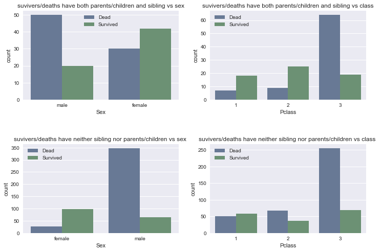

```python
#enabling the cell for multiple plots
fig, ax1 = plt.subplots(2,2)
fig.subplots_adjust(hspace=.5)

#setting titles
ax1[0][0].set_title('suvivers/deaths have both parents/children and sibling vs sex')
ax1[0][1].set_title('suvivers/deaths have both parents/children and sibling vs class')
ax1[1][0].set_title('suvivers/deaths have neither sibling nor parents/children vs sex ')
ax1[1][1].set_title('suvivers/deaths have neither sibling nor parents/children vs class ')

#showing the plots with legends
sns.countplot(x = "Sex", hue = "Survived", data=passangers_with_parents_and_sib, ax = ax1[0,0])
ax1[0][0].legend(('Dead','Survived'),loc='best')

#showing the plots with legends
sns.countplot(x = "Pclass", hue = "Survived", data=passangers_with_parents_and_sib, ax = ax1[0,1])
ax1[0][1].legend(('Dead','Survived'),loc='best')

#showing the plots with legends
sns.countplot(x = "Sex", hue = "Survived", data=passangers_with_no_parents_and_sib, ax = ax1[1,0])
ax1[1][0].legend(('Dead','Survived'),loc='best')

#showing the plots with legends
sns.countplot(x = "Pclass", hue = "Survived", data=passangers_with_no_parents_and_sib, ax = ax1[1,1])
ax1[1][1].legend(('Dead','Survived'),loc='best')
```

```python
print passangers_with_sib.groupby(['Pclass','Sex']).mean()['Survived']
print passangers_with_no_sib.groupby(['Pclass','Sex']).mean()['Survived']
print passangers_with_parents_childrens.groupby(['Pclass','Sex']).mean()['Survived']
print passangers_with_no_parents_childrens.groupby(['Pclass','Sex']).mean()['Survived']
print passangers_with_parents_but_no_sib.groupby(['Pclass','Sex']).mean()['Survived']
print passangers_with_sib_but_no_parents.groupby(['Pclass','Sex']).mean()['Survived']
print passangers_with_parents_and_sib.groupby(['Pclass','Sex']).mean()['Survived']
print passangers_with_no_parents_and_sib.groupby(['Pclass','Sex']).mean()['Survived']
```

```
Pclass  Sex
1       female    0.955556
        male      0.470588
2       female    0.906250
        male      0.250000
3       female    0.380952
        male      0.155844
Name: Survived, dtype: float64
Pclass  Sex
1       female    0.979592
        male      0.329545
2       female    0.931818
        male      0.118421
3       female    0.592593
        male      0.129630
Name: Survived, dtype: float64
Pclass  Sex
1       female    0.933333
        male      0.391304
2       female    0.967742
        male      0.473684
3       female    0.372881
        male      0.215686
Name: Survived, dtype: float64
Pclass  Sex
1       female    0.984375
        male      0.363636
2       female    0.888889
        male      0.089888
3       female    0.588235
        male      0.121622
Name: Survived, dtype: float64
Pclass  Sex
1       female    1.000000
        male      0.307692
2       female    1.000000
        male      0.500000
3       female    0.523810
        male      0.500000
Name: Survived, dtype: float64
```

[output cut: 9 more lines]

```
1       female    0.866667
        male      0.500000
2       female    0.947368
        male      0.466667
3       female    0.289474
        male      0.177778
Name: Survived, dtype: float64
Pclass  Sex
1       female    0.970588
        male      0.333333
2       female    0.906250
        male      0.097222
3       female    0.616667
        male      0.121212
Name: Survived, dtype: float64
```

From the above graphs and information we see some thing unexpected, we see that females were had less survival chance if they are with sibling or parents or children on the otherhand men were have a very little higher chance to survive then females if they have siblings or parents or childrens.

**Overall the above analysis didn't get us much information.**

## Analyse the data by grouping into age group

In this part we are going to group all the passangers into three groups

- child (less than 18)
- adult (between 18 to 60)
- old (above 60)

we did this kind of analysis above but this time we are going to make distinction about who is child and who is adult and who is old.

```python
def group_by_age(age):
    '''Funtion to group the passangers based on their ages'''
    if age < 18:
        return 'child'
    elif age > 60:
        return 'old'
    else:
        return 'adult'

titanic_more_clean_data['AgeGroup'] = titanic_more_clean_data['Age'].apply(group_by_age)
```

```python
titanic_more_clean_data.head()
```

|  | Survived | Pclass | Sex | Age | SibSp | Parch | AgeGroup |
| --- | --- | --- | --- | --- | --- | --- | --- |
| 0 | 0 | 3 | male | 22.0 | 1 | 0 | adult |
| 1 | 1 | 1 | female | 38.0 | 1 | 0 | adult |
| 2 | 1 | 3 | female | 26.0 | 0 | 0 | adult |
| 3 | 1 | 1 | female | 35.0 | 1 | 0 | adult |
| 4 | 0 | 3 | male | 35.0 | 0 | 0 | adult |

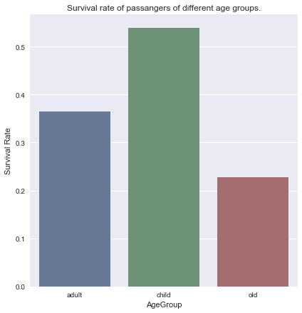

```python
#sowing the plot
sns.factorplot('AgeGroup', 'Survived',data = titanic_more_clean_data, ci=None, size=6, kind="bar")

#setting the label and title
plt.ylabel('Survival Rate')
sns.plt.title('Survival rate of passangers of different age groups.')
```

Here we can see that children are definetly the one who have the highest survival rate followed by adults and the last old passangers

##### lets see how many childrens are with out there parents and how it will effect their survival

```python
#filtering data on the basis of parents
children_without_parent = titanic_more_clean_data[(titanic_more_clean_data['AgeGroup'] == 'child') &
                                                  (titanic_more_clean_data['Parch'] == 0)]
children_with_parent = titanic_more_clean_data[(titanic_more_clean_data['AgeGroup'] == 'child') &
                                                  (titanic_more_clean_data['Parch'] > 0)]
print "Survival percentage of childrens with their parents is {}".format(children_with_parent.mean()['Survived']*100)
print "Survival percentage of childrens without their parents is {}".format(children_without_parent.mean()['Survived']*100)
```

```
Survival percentage of childrens with their parents is 55.5555555556
Survival percentage of childrens without their parents is 50.0
```

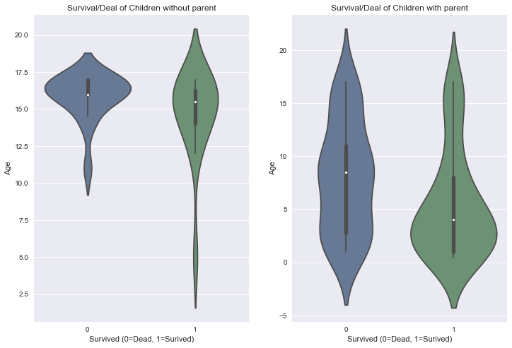

```python
fig, ax = plt.subplots(1,2)

#setting title of graphs
ax[0].set_title('Survival/Deal of Children without parent')
ax[1].set_title('Survival/Deal of Children with parent')

#plotting graph
sns.violinplot(x="Survived", y="Age", data=children_without_parent,ax=ax[0])

#setting X labels
ax[0].set_xlabel('Survived (0=Dead, 1=Surived)')

#plotting graph
sns.violinplot(x="Survived", y="Age", data=children_with_parent,ax=ax[1])

#setting X labels
ax[1].set_xlabel('Survived (0=Dead, 1=Surived)')
```

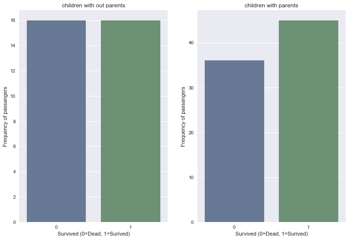

```python
fig, ax = plt.subplots(1,2)

#setting titles
ax[0].set_title('children with out parents')
ax[1].set_title('children with parents')

#plotting count plot graph
sns.countplot(x='Survived',data = children_without_parent,ax=ax[0]);

#Setting X and Y label
ax[0].set_ylabel('Frequency of passangers')
ax[0].set_xlabel('Survived (0=Dead, 1=Surived)')

#plotting count plot graph
sns.countplot(x='Survived',data = children_with_parent,ax=ax[1]);

#Setting X and Y label
ax[1].set_ylabel('Frequency of passangers')
ax[1].set_xlabel('Survived (0=Dead, 1=Surived)')
```

From this we can easily say that the childrens who are **without** their parents have not survived in much percentage as they survived with parents. It might be because they were **with** their caretakers/nanies who at the time of calamity thought for their own life rather than the child. Or they must be travelling alone.

**Now we are going to see if old people has more survival rate if they were with their siblings**

```python
#filtering data on the basis of sibling
old_with_sibling = titanic_more_clean_data[(titanic_more_clean_data['AgeGroup'] == 'old') &
                         (titanic_more_clean_data['SibSp'] > 0)]
old_not_with_sibling = titanic_more_clean_data[(titanic_more_clean_data['AgeGroup'] == 'old') &
                         (titanic_more_clean_data['SibSp'] == 0)]

print "Survival percentage of old passangers with the siblings is {}".format(old_with_sibling.mean()['Survived']*100)
print "Survival percentage of old passangers without siblings is {}".format(old_not_with_sibling.mean()['Survived']*100)
```

```
Survival percentage of old passangers with the siblings is 33.3333333333
Survival percentage of old passangers without siblings is 21.0526315789
```

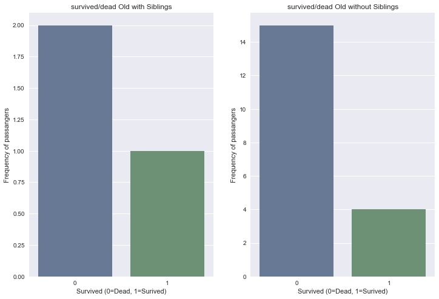

```python
fig, ax = plt.subplots(1,2)

#setting titles
ax[0].set_title('survived/dead Old with Siblings')
ax[1].set_title('survived/dead Old without Siblings')

#plotting count plot graph
sns.countplot(x='Survived',data = old_with_sibling,ax=ax[0]);

#Setting X and Y label
ax[0].set_ylabel('Frequency of passangers')
ax[0].set_xlabel('Survived (0=Dead, 1=Surived)')

#plotting count plot graph
sns.countplot(x='Survived',data = old_not_with_sibling,ax=ax[1]);

#Setting X and Y label
ax[1].set_ylabel('Frequency of passangers')
ax[1].set_xlabel('Survived (0=Dead, 1=Surived)')
```

**Now Lets see the adult passangers and their surivival rate with or without their siblings**

```python
#filtering data on the basis of siblings
adult_with_sibling = titanic_more_clean_data[(titanic_more_clean_data['AgeGroup'] == 'adult') &
                         (titanic_more_clean_data['SibSp'] > 0)]
adult_not_with_sibling = titanic_more_clean_data[(titanic_more_clean_data['AgeGroup'] == 'adult') &
                         (titanic_more_clean_data['SibSp'] == 0)]

print "Survival percentage of old passangers with the siblings is {}".format(adult_with_sibling.mean()['Survived']*100)
print "Survival percentage of old passangers with the siblings is {}".format(adult_not_with_sibling.mean()['Survived']*100)
```

```
Survival percentage of old passangers with the siblings is 46.6666666667
Survival percentage of old passangers with the siblings is 32.6007326007
```

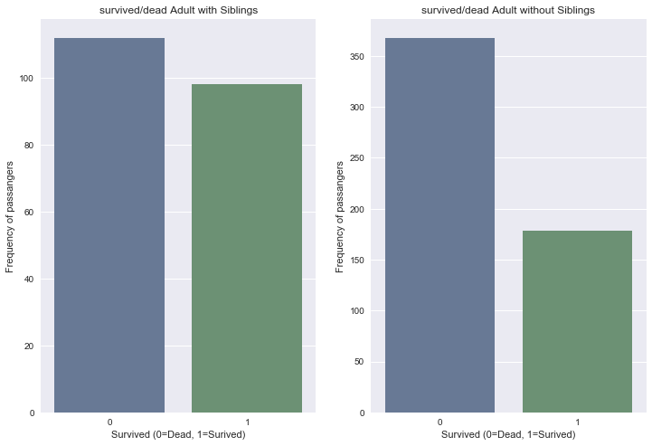

```python
fig, ax = plt.subplots(1,2)

#setting titles
ax[0].set_title('survived/dead Adult with Siblings')
ax[1].set_title('survived/dead Adult without Siblings')

#plotting count plot graph
sns.countplot(x='Survived',data = adult_with_sibling,ax=ax[0]);

#Setting X and Y label
ax[0].set_ylabel('Frequency of passangers')
ax[0].set_xlabel('Survived (0=Dead, 1=Surived)')

#plotting count plot graph
sns.countplot(x='Survived',data = adult_not_with_sibling,ax=ax[1]);

#Setting X and Y label
ax[1].set_ylabel('Frequency of passangers')
ax[1].set_xlabel('Survived (0=Dead, 1=Surived)')
```

Here we can see a relevant difference between survival of adult passangers who were and were not with their siblings, the surivial rate for adult passangers with their sibling is significantly higher than the adult passangers who were not with their siblings.

**So I think we can now answer our final question which was**

**Q.**were there any substantial difference in survival rate between the people with siblings, parents or childrens and the people with no sibling, parents or childrens?

## Conclusion

#### Before we jump into any conlusion just remeber one thing co-relation does not imply causation.

###### limitaitons

- The conclusions are just based on the analysis I have done.
- Also one of the limitation is that the data is a subset of the orignal data.
- Almost 20 % of the data is with out age, which may have an effect on my analysis.

# Resources

- https://storage.googleapis.com/supplemental_media/udacityu/5435548805/numpy_pandas_cheatsheet.pdf
- udacity vedios and exercise.
- http://matplotlib.org/api/pyplot_api.html
- https://stackoverflow.com/questions/26266362/how-to-count-the-nan-values-in-the-column-in-panda-data-frame
- https://pandas.pydata.org/pandas-docs/stable/generated/pandas.DataFrame.drop_duplicates.html
- https://pandas.pydata.org/pandas-docs/stable/generated/pandas.DataFrame.hist.html
- http://seaborn.pydata.org/generated/seaborn.boxplot.html
- http://seaborn.pydata.org/generated/seaborn.regplot.html
- https://seaborn.pydata.org/generated/seaborn.countplot.html
- http://seaborn.pydata.org/tutorial/categorical.html
- https://stackoverflow.com/questions/5159065/need-to-add-space-between-subplots-for-x-axis-label-maybe-remove-labelling-of-a